# Uusberg, A., Ford, B., Uusberg, H., & Gross, J. J. (2023).

Reappraising reappraisal: An expanded view. Cognition and Emotion, 0(0), 1–14. https://doi.org/10.1080/02699931.2023.2208340

Last update at: 2023-06-06

Back to index

# Abstract / Key Points

I think this framework is helpful in thinking about (1) when people are reluctant to reappraise, what prevents them? (what tpyes/levels of representation?; what operation was not at play?) (2) when people failed to reppraise, what went wrong?

- pain points at frequency and/or efficacy

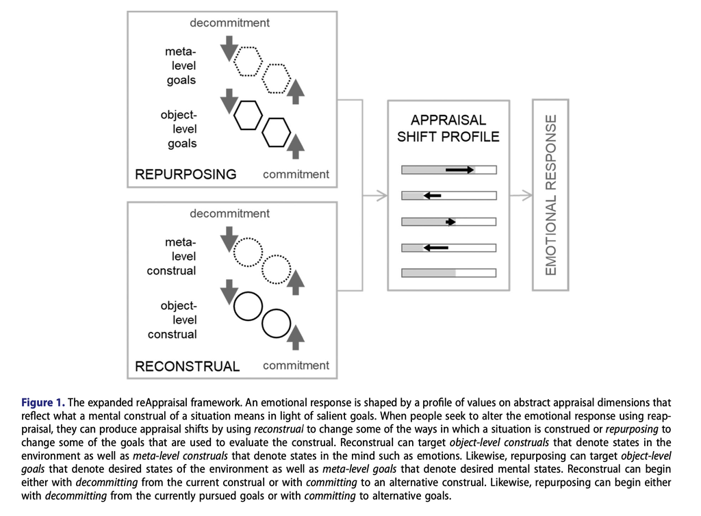

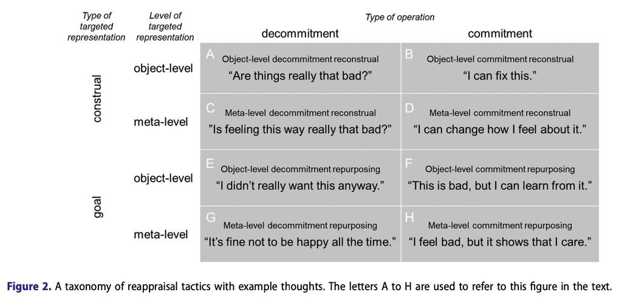

Type of targeted representation:

- reconstrual: changes in perceptions/ subjective meaning of the the current state
- repurposing: changes in the desired states

Type of operation:

- commitment: engage in alternative representations (without necessarily undermining the current representation)
- decommitment: disengage from the currently dominant representations (without necessarily having an alternative representation)

Also see:

- Ehring, T., & Woud, M. L. (2023). Towards a better understanding of the role of reappraisal in psychopathology and its treatment: Commentary on “Reappraising Reappraisal: An Expanded View.” Cognition and Emotion, 0(0), 1–6. https://doi.org/10.1080/02699931.2023.2208341
  - Question about their dinstinction of meta-level and objective-level representation; raise a good point about their figure 2 about “Is feeling this way really that bad” as a meta-level construal vs. “It’s fine to not be happy all the time” as a meta-level repurposing
- Uusberg, A., Taxer, J. L., Yih, J., Uusberg, H., & Gross, J. J. (2019). Reappraising Reappraisal. Emotion Review, 11(4), 267–282. https://doi.org/10.1177/1754073919862617
- Tamir, M., Halperin, E., Porat, R., Bigman, Y. E., & Hasson, Y. (2019). When there’s a will, there’s a way: Disentangling the effects of goals and means in emotion regulation. Journal of Personality and Social Psychology, 116(5), 795–816. https://doi.org/10.1037/pspp0000232

Back to index